## How many people are there in each enrollment

## How many of those people fail the first question

Welcome to the course Why would anyone want your data? Preserving privacy in cloud storage: privacy by design Staying safe online: personal perspectives Privacy online and offline

## How many of those got the quiz correct

## Was there a relation between if you watched the video or not and succeeding the quiz

### Total views by each year for each video

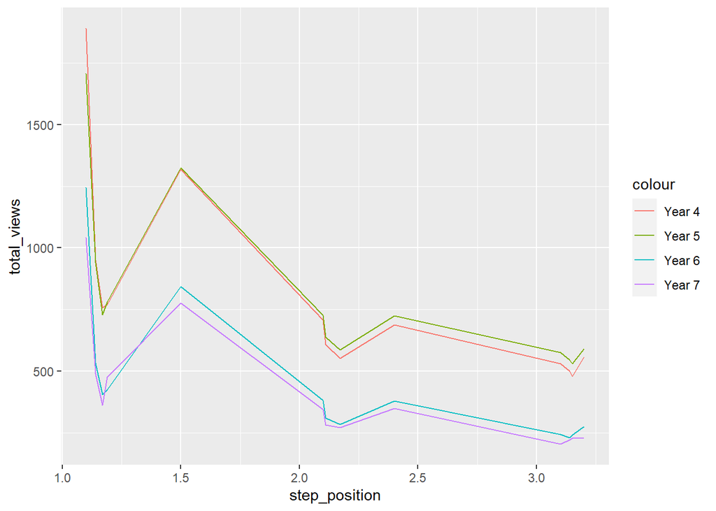

## I decided to see if there was a relation between people watching the videos and being able to answer the questions correctly. Therefore i took the data from the enrollemnts.csv to check for each year the amount of people that were enrolled. I decided to check for the last 4 years.

### Year 7

```
## [1] 2342
```

### Year 6

```
## [1] 3175
```

### Year 5

```
## [1] 3544
```

### Year 4

```
## [1] 3992
```

Then I found the amount of people that got the first question correct by each year. I eliminated any any data that wasn’t correctly inputted (NA).

### Year 7

```
## [1] 570
```

### Year 6

```
## [1] 619
```

### Year 5

```
## [1] 1040
```

### Year 4

```
## [1] 1034
```

Then I decided to measure the views of total views for the 5 videos that were uploaded and you were supposed to see before answering the quiz for each year. I then found the average total views for all the 5 videos combined.

### Year 7

```
## [1] 629
```

### Year 6

```
## [1] 689.4
```

### Year 5

```
## [1] 1095.8
```

### Year 4

```
## [1] 1137.4
```

I then decided to divide the mean mean videos over the enrollment number so all the numbers will be proportionally equal.

### Year 7

```
## [1] 0.2685739
```

### Year 6

```
## [1] 0.2171339
```

### Year 5

```
## [1] 0.3091986
```

### Year 4

```
## [1] 0.2849198
```

From this data we can observe that most people that watched the people proportionally wise was at the 5th year with the 6th year coming last by a lot.

Now we are going to see who were the most people proportionally that got the most correct answer. We are going to achieve this by diving the question correctness by the enrollment size for each year.

### Year 7

```
## [1] 0.2433817
```

### Year 6

```
## [1] 0.1949606
```

### Year 5

```
## [1] 0.2934537
```

### Year 4

```
## [1] 0.259018
```

These were 4 cases for this module. If it was possible i would increase the data to be more precise with my measurements cause I know that 4 years are not that secure for the error handling but I can’t cause the data for the video stats doesn’t exist before year 3th.

I will now plot a graph to show you the data more clearly.

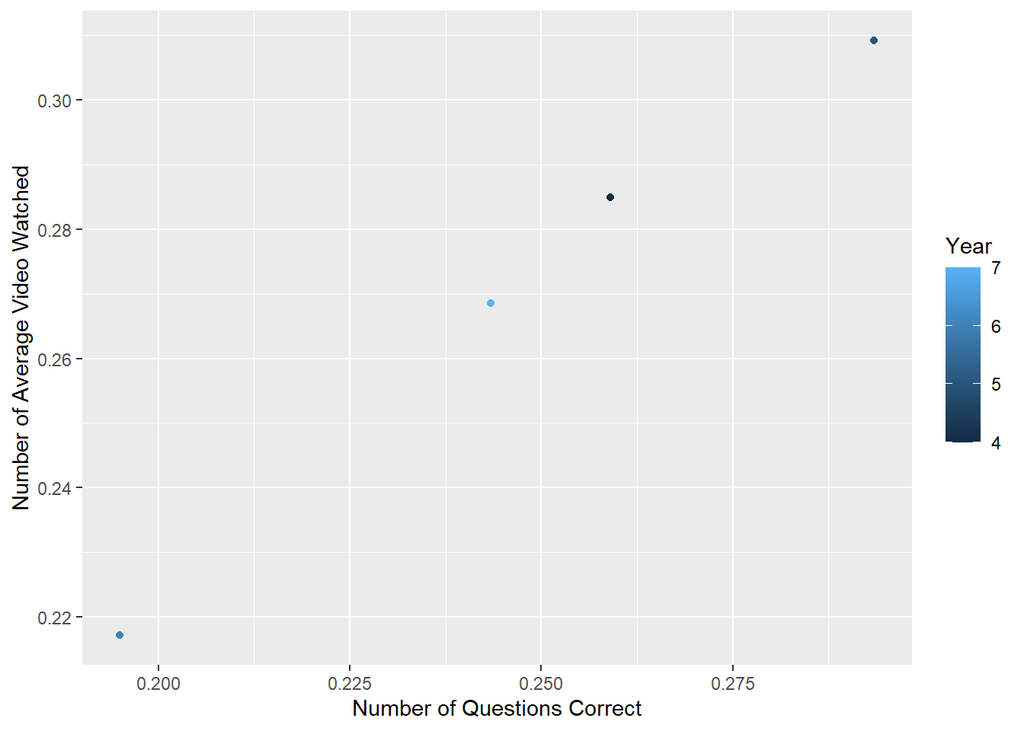

## Assumption

From this my assumption is that there is indeed a relation between the time to give to watch a video about the subject and answering the quiz question correctly even if the videos are not all relevant to the question being asked. It seems that people that will do good at the quiz are people that watch most if not all of the videos.

## What type of device did they use and did it have any relation with the outcome?

# Summary

I was given data for the video stats from the module cyber-security. I extracted the statistics for device usage.

# Assumptions

My Assumption is if there is a relation to what device you are using with the likelihood that you are going to watch the videos.

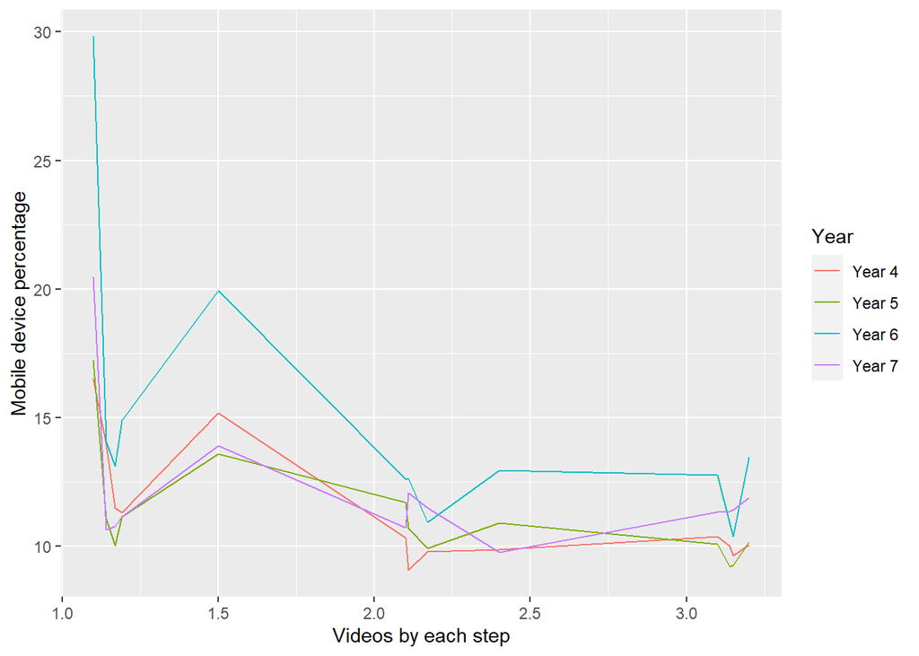

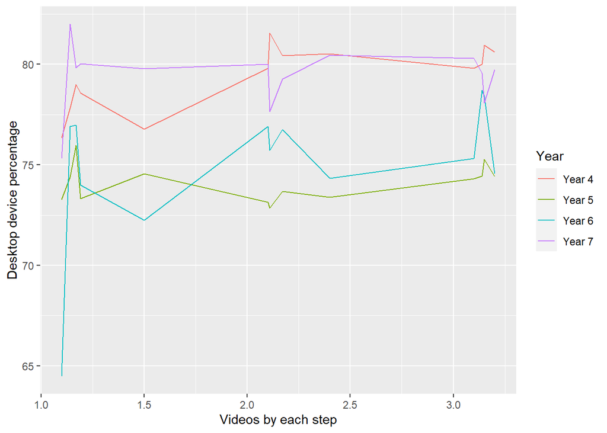

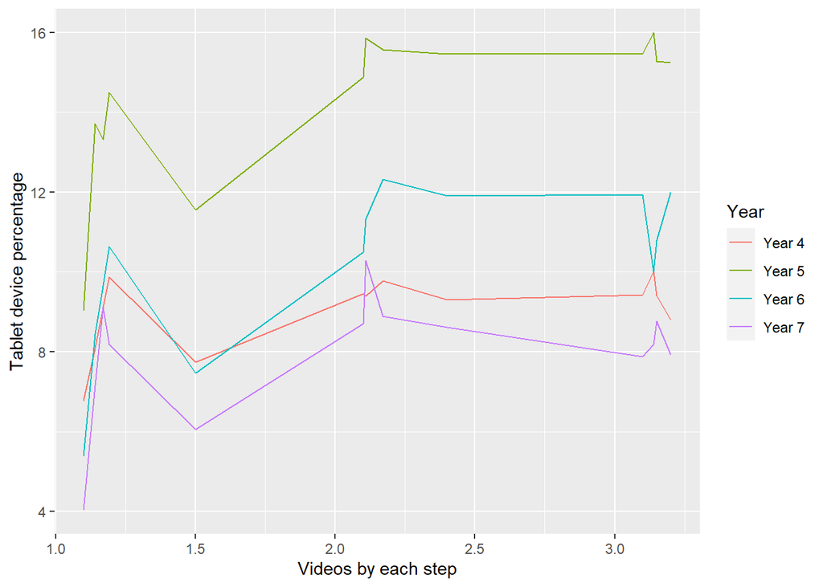

### Year 7

```
## [1] 0.3142613
```

### Year 6

```
## [1] 0.2513386
```

### Year 5

```
## [1] 0.4616253
```

### Year 4

```
## [1] 0.4063126
```

[figure not shown]

[figure not shown]

[figure not shown]

##Summarise

There doesn’t seem to be any relation between what device do you use and how well your results are in the quiz.